# Regression Analysis in R

## STAT 4101L

### Surya Lamichhane

```r
df = read.csv("~/Desktop/STAT4101L_all_files/train_insurance.csv", header = TRUE)
knitr::kable(head(df))
```

```
| age|sex    |    bmi| children|smoker |region    |   charges|health_cond |
|---:|:------|------:|--------:|:------|:---------|---------:|:-----------|
|  19|female | 27.900|        0|yes    |southwest | 16884.924|high        |
|  18|male   | 33.770|        1|no     |southeast |  1725.552|low         |
|  28|male   | 33.000|        3|no     |southeast |  4449.462|low         |
|  33|male   | 22.705|        0|no     |northwest | 21984.471|high        |
|  32|male   | 28.880|        0|no     |northwest |  3866.855|low         |
|  31|female | 25.740|        0|no     |southeast |  3756.622|low         |
```

```r
str(df)
```

```
'data.frame':	1000 obs. of  8 variables:
 $ age        : int  19 18 28 33 32 31 46 37 37 60 ...
 $ sex        : chr  "female" "male" "male" "male" ...
 $ bmi        : num  27.9 33.8 33 22.7 28.9 ...
 $ children   : int  0 1 3 0 0 0 1 3 2 0 ...
 $ smoker     : chr  "yes" "no" "no" "no" ...
 $ region     : chr  "southwest" "southeast" "southeast" "northwest" ...
 $ charges    : num  16885 1726 4449 21984 3867 ...
 $ health_cond: chr  "high" "low" "low" "high" ...
```

### Motivation

- John works for an Insurance company. The company wants to understand the impact of various factors on medical charges to determine the insurance premium.
- John is assigned the task of developing a relationship between medical charges and various underlying factors that can influence the medical cost.

Approach:

- John need to understand the association between medical charges and explanatory variables
- John must understand the concepts of regression.

### Learning Objectives

By the end of this lesson, you will be able to:

- Define correlation
- Perform regression analysis
- Build a regression model
- Analyze the assumptions of regression

### Mathematical Model

George Box (Statistician 1919-2013, UK): "All models are wrong, but some are useful." This statement emphasizes the inherent limitation of models in representing complex real-world phenomena perfectly.

- Models built upon assumptions and approximations that might not capture every factor influencing a situation.
- No model can encompass the entirety of the complexities inherent in the real world.

**Why models might be considered "wrong":**

- Simplifications: Models often simplify complex relationships or systems to make them understandable and solvable. This simplification might miss out on certain complexity that exist in reality.
- Assumptions: Models are based on assumptions about the data and the relationships between variables. If these assumptions are violated, the model might not hold true.
- Incompleteness: Models might not incorporate all relevant variables or factors that influence the outcome. They might overlook hidden variables or interactions that play a role.
  - Changing Dynamics: The world is dynamic, and situations evolve over time. A model built on historical data might become less accurate as new trends or influences emerge.
  - Human Error and Bias: Models are created by humans and can carry biases or errors in the selection of variables, data collection, or methodology.

However, despite these limitations and potential inaccuracies, models can still be incredibly useful. They provide frameworks for understanding, making predictions, and guiding decisions. Even if they don't represent reality perfectly, they can offer valuable insights and help us navigate and make sense of complex systems.

Acknowledging the imperfection of models encourages a cautious and critical approach, prompting continuous improvement, refinement, and exploration of better models that can more accurately represent reality within a given context.

### Correlation

Correlation coefficient measures the degree of association between two variables.

- Population correlation coefficient (Pearson's correlation coefficient) is denoted by $\rho$ (rho), and sample correlation coefficient denoted by r.
- Values of r lie between -1 and 1, $-1 \leq r \leq 1$.
- Correlation does not mean cause-and-effect relationship, but
- The existence of causation always implies correlation.
- In R, $r = cor(x,y)$.

### Sample correlation coefficient in R

```r
cat("correlation coefficient between age and hospital charges")
cor(df$age, df$charges)
cat("correlation coefficient between bmi and hospital charges")
cor(df$bmi, df$charges)
```

```
correlation coefficient between age and hospital charges
```

0.330647056828519

```
correlation coefficient between bmi and hospital charges
```

0.188470399103015

### Correlation diagnosis using scatter plot

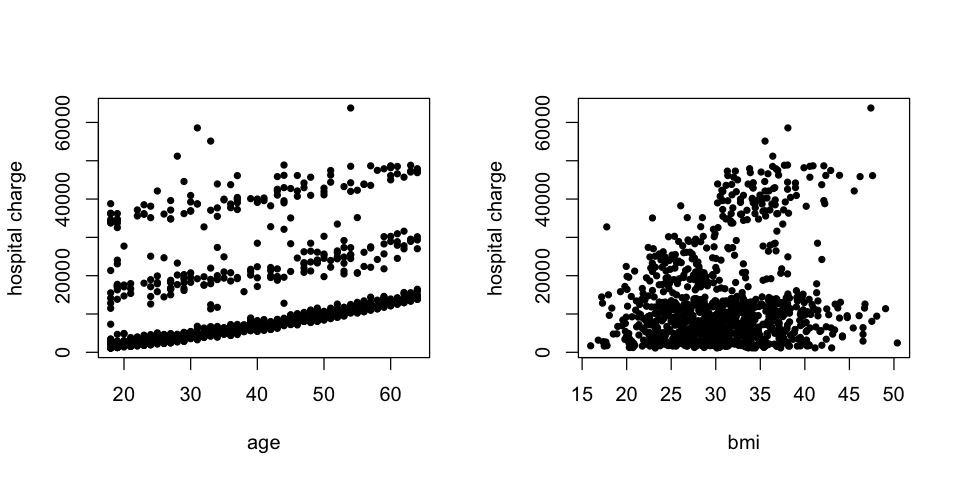

```r
options(repr.plot.width = 8, repr.plot.height = 4)
par(mfrow = c(1, 2))
plot(df$age, df$charges, xlab = 'age', ylab = 'hospital charge', type = 'p', pch = 20)
plot(df$bmi, df$charges,  xlab = 'bmi', ylab = 'hospital charge', type = 'p', pch = 20)
```

# Regression Analysis

It is a statistical technique of finding a functional relationship between variable of interest (target/dependent variable) to one or more independent or predictor variables.

The objective is to build a statistical model to:

- Describe the target and the variables that can explain the target variable called predictor/covariates/features.
- Find the association between target variable and predictor variable
- Predict the variable of interest
- Control the variable of interest

To explore additional concepts and more information, please see to the [link1](https://online.stat.psu.edu/stat462/node/151/), or [link2](https://iainpardoe.com/arm3e/teaching-resources/presentation-slides/)

## 1. Assumption of Linear Regression

- Linear relationship
- Independence of error
- Normality of error terms
- Equality of variance (Homoscedasticity)
- Predictors are linearly independent (No or little multi-collinearity)

### Simple Linear Regression

Simple linear regression is a linear regression model with a single predictor variable.

- Regression line is denoted by $y = \beta_0 + \beta_1 X + \epsilon$, and
- the fitted line denoted by $\hat y = \hat\beta_0 + \hat\beta_1 X$, where
- $\hat\beta_0$ and $\hat\beta_1$ are estimated values of parameters $\beta_0$ and $\beta_1$.

### Multiple Linear Regression (MLR)

Multiple linear regression is a statistical technique used to model the relationship between multiple independent variables (predictors) and a single dependent variable (response). It extends simple linear regression, which models the relationship between one independent variable and a dependent variable, to cases where there are two or more independent variables.

The general form of multiple linear regression can be expressed as:

$$ y = \beta_0 + \beta_1 x_1 + \beta_2 x_2 + \ldots + \beta_p x_p + \epsilon $$

Where:

- $y$ is the dependent variable (response).
- $x_1, x_2, \ldots, x_p$ are the independent variables (predictors).
- $\beta_0$ is the intercept (the value of $y$ when all predictors are zero).
- $\beta_1, \beta_2, \ldots, \beta_p$ are the coefficients (regression coefficients) representing the change in $y$ associated with a one-unit change in each predictor, holding all other predictors constant.
- $\epsilon$ is the error term representing the discrepancy between the observed and predicted values.

In matrix notation, the equation can be written as:

\begin{eqnarray} && \mathbf{y} = \mathbf{X}\; \boldsymbol{\beta} + \epsilon, \ \text{so} \ \hat{\mathbf{y}} = \mathbf{X}\;\hat{\boldsymbol{\beta}}, \\ \implies && E[\mathbf{y}] = \mathbf{X}\; \boldsymbol{\beta} = E[\hat{\mathbf{y}}],\\ \implies && \hat{E}{\hat{[\mathbf{y}]}} = \mathbf{X}\;\hat{\boldsymbol{\beta}}. \end{eqnarray}

The final equation indicates that the estimated expected value of the predicted values $\hat{y}$ from the regression model is equal to $\mathbf{X}\;\hat{\boldsymbol{\beta}}$.

- The term $\epsilon$ is the error term, accounting for all other factors influencing y that cannot be captured by the model.
- Usual assumption, $\epsilon_i \overset{\mathrm{iid}}{\sim} \mathcal{N}(0,\sigma^2)$, having a mean of zero, being normally distributed, and having constant variance $\sigma^2$ (homoscedasticity)
- This assumption implies that $y_i \overset{\mathrm{iid}}{\sim} \mathcal{N}(X_i^T\beta,\sigma^2)$, data values are independent and identically distributed (iid) and have normal distribution

Therefore, this assumption holds significant importance while building a regression model

#### Linear Regression in R

Syntax:

```
lm(formula, data, subset, weights, na.action,
   method = "qr", model = TRUE, x = FALSE, y = FALSE, qr = TRUE,
   singular.ok = TRUE, contrasts = NULL, offset, ...)
```

Example 1. Estimation of regression equation of hospital chargrs on age and regression output

#### First check the distribution of the target varaible (hospital chargrs) using histogram

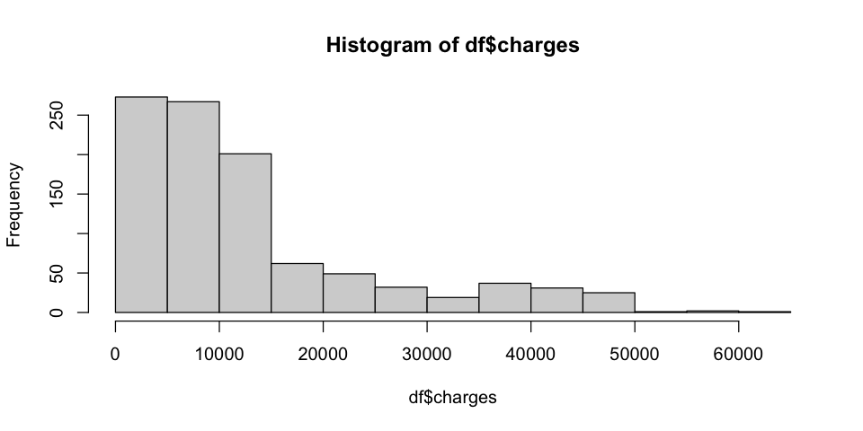

```r
hist(df$charges)
```

- The above histogram shows the data values are far way from normally assumption (mild departures from normality is ok)
- If the data values significantly deviate from the normality assumption in a regression model, it can affect the reliability and validity of the model's results
- It's essential to consider alternative modeling approaches or transformations that could make the data more susceptible to the assumptions of linear regression.
- These might lead to use robust regression techniques such as data transformations (like log or square root transformations), or non-linear models that don't rely heavily on normality assumptions.

#### Check the distribution of the log of target varaible (hospital chargrs) using histogram

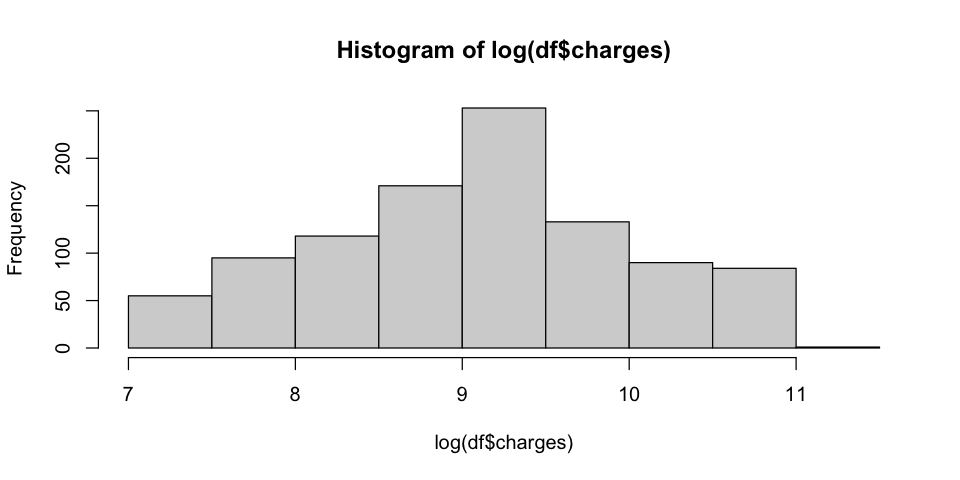

```r
hist(log(df$charges))
```

[output not shown]

If applying a log transformation makes the histogram of the data much closer to a normal distribution, it can often improve the performance of linear models, as these models typically assume that the data follows a normal distribution.

However, whether it's "better" depends on the specific context of your analysis and the goals of your modeling. Here are a few considerations:

- Model Assumptions: Linear models assume certain relationships between the variables, including normality of residuals. If the log transformation makes the data more consistent with these assumptions, it might lead to more reliable model estimates.
- Robustness: Sometimes, transformations can make the model more sensitive to outliers. While a log transformation often reduces the impact of extreme values, it's not immune to this issue. So, you should assess the robustness of your model to outliers after applying the transformation.
- Context: Consider the specific context of your analysis and whether a log transformation makes sense theoretically. For example, if your data represents counts or monetary values, a log transformation might align better with the underlying process.
- Comparison: Before and after applying the transformation, compare the performance of your model using appropriate metrics (e.g., R-squared, RMSE) and assess whether the improvement justifies the transformation.

```r
df$log_charges = log(df$charges)
fit1 = lm(log_charges~age, data = df)
summary(fit1)
```

```
Call:
lm(formula = log_charges ~ age, data = df)

Residuals:
    Min      1Q  Median      3Q     Max
-1.2563 -0.4112 -0.2973  0.3446  2.2869

Coefficients:
            Estimate Std. Error t value Pr(>|t|)
(Intercept) 7.610892   0.071364  106.65   <2e-16 ***
age         0.037122   0.001697   21.88   <2e-16 ***
---
Signif. codes:  0 ‘***’ 0.001 ‘**’ 0.01 ‘*’ 0.05 ‘.’ 0.1 ‘ ’ 1

Residual standard error: 0.7589 on 998 degrees of freedom
Multiple R-squared:  0.3242,	Adjusted R-squared:  0.3235
F-statistic: 478.8 on 1 and 998 DF,  p-value: < 2.2e-16
```

```r
#coefficients(fit1)
coef(fit1)
```

**(Intercept)**

7.61089156172694

**age**

0.0371215505756222

### 2. Interpretation of coefficients for numerical covariates

- The line $\hat{y} = \hat{\beta_0} + \hat{\beta_1} X$ is called the line of best fit or line of least squares
- $E[\hat y] = y$,
- $\hat{E}{\hat{[\mathbf{y}]}} = b_0 + \hat{\beta_1} X$ at given x: The predicted value of y at given X is $\hat y$ is the estimated expected value at x.

### 3. Choosing the Best Line (Ordinary Least Square Regression)

- predict $y = \beta_0 + \beta\ x$, so that $\sum(\hat{y_i} −y_i)^2$ is minimum, that is
- estimate $\beta_0$ and $\beta$ for which $\sum\big((\beta_0 + \beta x_i) − y_i\big)^2$ is minimum.

### Linear Regression Diagnostic

Diagnosing a linear regression model involves assessing its assumptions and examining various aspects to ensure the model's validity and reliability. Here are some common diagnostics used for linear regression models

1. Metrics to determine how well regression model fit the data (goodness of fit)  
   a. R-squared  
   b. Adjusted R-squared  
   c. Likelihood  
   d. AIC  
   e. BIC
1. Residual Analysis: Residuals are the differences between observed and predicted values. Analyzing residuals helps check if they meet the assumptions of linear regression:  
   a. Residuals vs. Fitted Values Plot: A scatter plot of residuals against predicted values to check for patterns or heteroscedasticity (unequal variance).  
   b. Normality of Residuals: Checking if residuals follow a normal distribution using a histogram or a Q-Q plot.  
   c. Statistical test for normality of residuals
1. Homoscedasticity: Verifying that the residuals have constant variance across all levels of the predictors. Heteroscedasticity might indicate a violation of the regression assumptions.
1. Linearity: Assessing if the relationship between predictors and the response variable is adequately captured by the linear model.  
   a. This can involve plotting the predictor against the response variable before modeling.  
   b. Test overall model significane,  
   c. Coefficient Estimates: Assessing the coefficients of the predictors for significance and interpreting their impact on the dependent variable.  
   d. Test for significance of predictor: Test whether the predictor variable is statistically significant or not in predicting the response varaible
1. Colinearity: Examining the correlation between predictor variables to ensure they are not highly correlated, as high colinearity can affect the model's stability and interpretation.  
   a. Variance influence factor (VIF): a measure used in regression analysis to detect multicollinearity among predictor variables  
   b. If VIF is greater than 5 (strong assumption), we consider that the corresponding varaible is linearly explained by other variables c. VIF > 10, loose assumption
1. Outlier and Influential Detection: Identifying influential data points or outliers that can significantly impact the regression results.  
   a. Cook's Distance: Measures the influence of each observation on the model's coefficients.  
   b. Outlier Analysis: Identifying observations with unusually large residuals
1. Leverage and Cook's Distance: Identifying observations with high leverage (extreme values in predictor variables) and their impact on the regression coefficients.
1. Model usefulness (Model predictability at new value of explanatory variables)

Eestimated data variance in R

```r
#compute varaince for model 1
summary(fit1)$sigma^2
```

0.576005084976164

### Multiple linear regression with numerical covariates

```r
### Multiple linear regression
MLR_model = log_charges ~ age + bmi + children
fit2 = lm(log_charges ~ age + bmi + children, data = df)
```

```r
#compute varaince for model 2
summary(fit2)$sigma^2
```

0.559150101667072

### 1. Check how good is regression.

Regression is assessed based on the residual deviations.

- Total deviation = Unexplained deviation + Explained deviation, i.e.
- $y_i- \bar{y} = (y_i - \hat{y_i}) + (\hat{y_i} - \bar{y})$.
- Once the linear relationship is determined, one can analyze the strength of the relationship

$$ \begin{matrix} Σ(y_i - ȳ)^2 & = & Σ(y_i - ŷ_i)^2 & + & Σ(ŷ_i - ȳ)^2\\ \text{SST (Total sum of squared)}& & \text{SSE (Sum of squares of error)} & & \text{SSR (Sum of squares of regression)} \end{matrix} $$

#### Coefficient of determination (R-squared)

R-squared shows the strength of linear relationship between target variable with its predictors.

#### Adjusted R-squared

Adjusted-$R^2$ is the coefficient of determination corrected for degree of freedom.

- Adjusted R-squared doesn’t always increase when new variables are introduced in the regression model.
- It will increase if increase in $R^2$ is higher than expected while adding variables in the model, otherwise decreases.
- It is defined as: $$\text{adjusted } R^2 = 1- \frac{\frac{SSE}{𝑛−(𝑘+1)}} {\frac{SST}{(𝑛−1)}}, $$

where n = Sample size, k = No. of parameters = p + 2, (if you have p many parameters).

```r
summary(fit2)
```

```
Call:
lm(formula = log_charges ~ age + bmi + children, data = df)

Residuals:
    Min      1Q  Median      3Q     Max
-1.2555 -0.4147 -0.3034  0.4091  2.2708

Coefficients:
            Estimate Std. Error t value Pr(>|t|)
(Intercept) 7.238357   0.134822  53.688  < 2e-16 ***
age         0.036384   0.001684  21.611  < 2e-16 ***
bmi         0.009514   0.003940   2.415   0.0159 *
children    0.100104   0.019750   5.069 4.78e-07 ***
---
Signif. codes:  0 ‘***’ 0.001 ‘**’ 0.01 ‘*’ 0.05 ‘.’ 0.1 ‘ ’ 1

Residual standard error: 0.7478 on 996 degrees of freedom
Multiple R-squared:  0.3453,	Adjusted R-squared:  0.3433
F-statistic: 175.1 on 3 and 996 DF,  p-value: < 2.2e-16
```

The estimated model is $$ \widehat{\text{log(Hospital charge)}} = 7.2384 + 0.0364 \;age + 0.0095\; bmi + 0.1001 \;children$$

#### Likelihood

The likelihood of a regression model refers to the probability of observing the given data points given the parameters and assumptions of the regression model.

- It measures how well the model, with its specified parameters, explains or predicts the observed data.
- A higher likelihood indicates that the model does a better job of explaining the observed data.

$$ \text{Likelihood} = p(y|model)$$

```r
log_lik_SLR = logLik(fit1) # of previous simple model
log_lik_MLR = logLik(fit2) # of Multiple linear regression model

cat("Log-likelihood of previous simple model is: ", log_lik_SLR, "\n")
cat("Log-likelihood of MLR is: ", log_lik_MLR, "\n")
```

```
Log-likelihood of previous simple model is:  -1142.118
Log-likelihood of MLR is:  -1126.266
```

#### AIC and BIC

Likelihood always increases when adding more parameters in the model (so is covariates), but model complexity also increases. Adding predictor variables is not always beneficial due to the model complexity. Hence, in order to balance the goodness of fit and model complexity other statistical measure that are in prectice are

a. AIC (Akaike Information Criterion):

$$AIC = - 2 \hat{L} + 2K$$ Where k represents the number of parameters in the model, and $\hat{L}$ is the maximum value of the likelihood function of the model.

- k = p + 2, if there are p covaraites in the model
- parameters for 1 intercept, 1 variance, p coefficients for covariates

  b. BIC (Bayesian Information Criterion): $$BIC = - 2 \hat{L} + k \log(n) $$
  - A model with good fit has lowest AIC and BIC.
  - We choose model based on either AIC or BIC or both

#### Comparision of SLR Model1 with MLR model2

```r
n = nrow(df)
results = data.frame(
    matric = c("R-squared", "Adj-R^2", "Log-lik", "AIC", "BIC"),
    Model1 = c(summary(fit1)$r.squared, summary(fit1)$adj.r.squared, logLik(fit1),  AIC(fit1),  BIC(fit1)),
    Model2 = c(summary(fit2)$r.squared, summary(fit2)$adj.r.squared,  logLik(fit2), AIC(fit2),  BIC(fit2))
)

print(results)
```

```
     matric        Model1       Model2
1 R-squared     0.3242095     0.345299
2   Adj-R^2     0.3235323     0.343327
3   Log-lik -1142.1181367 -1126.265861
4       AIC  2290.2362735  2262.531721
5       BIC  2304.9595393  2287.070498
```

#### Observed vs fitted plot

Visualization of observed vs fitted values:

Plotting observed versus fitted values in a regression analysis is a common diagnostic tool to assess the model's performance. This plot compares the actual observed values of the dependent variable against the predicted or fitted values obtained from the regression equation.

$$\text{Fitted values: }\hat{y} = \hat\beta_0 + \hat\beta X.$$

```r
fit_values1 = fit1$fitted.values
fit_values2 = fitted(fit2)
```

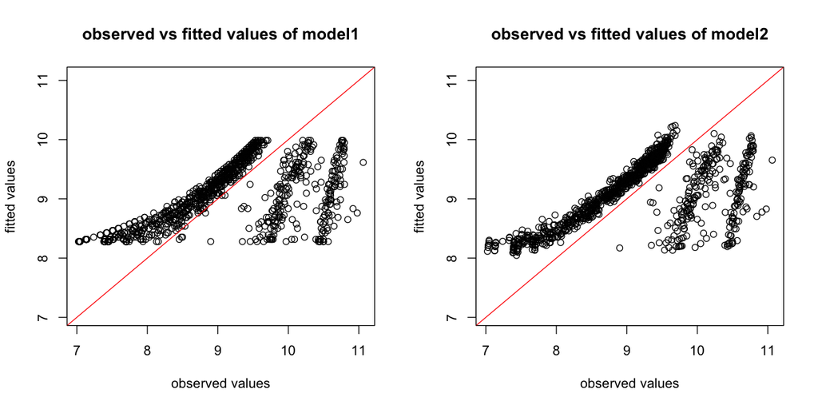

```r
options(repr.plot.width = 10, repr.plot.height = 5)
par(mfrow = c(1,2))
plot(df$log_charges, fit_values1, xlim = range(df$log_charges, fit_values1),
     ylim = range(df$log_charges, fit_values1), xlab = "observed values",
     ylab = "fitted values", type = 'p', main = "observed vs fitted values of model1")
# x = y line
abline(0,1, col = 'red')
plot(df$log_charges, fit_values2, xlim = range(df$log_charges, fit_values2),
     ylim = range(df$log_charges, fit_values2), xlab = "observed values",
     ylab = "fitted values", type = 'p', main = "observed vs fitted values of model2")
# x = y line
abline(0,1, col = 'red')
```

### 2. Residual Analysis (Model1)

residuals = Observed - predicted

$$\text{residuals} = y -\hat{y}$$

#### 1. Scatter plot of residuals against predicted values

- check for patterns or heteroscedasticity (unequal variance)

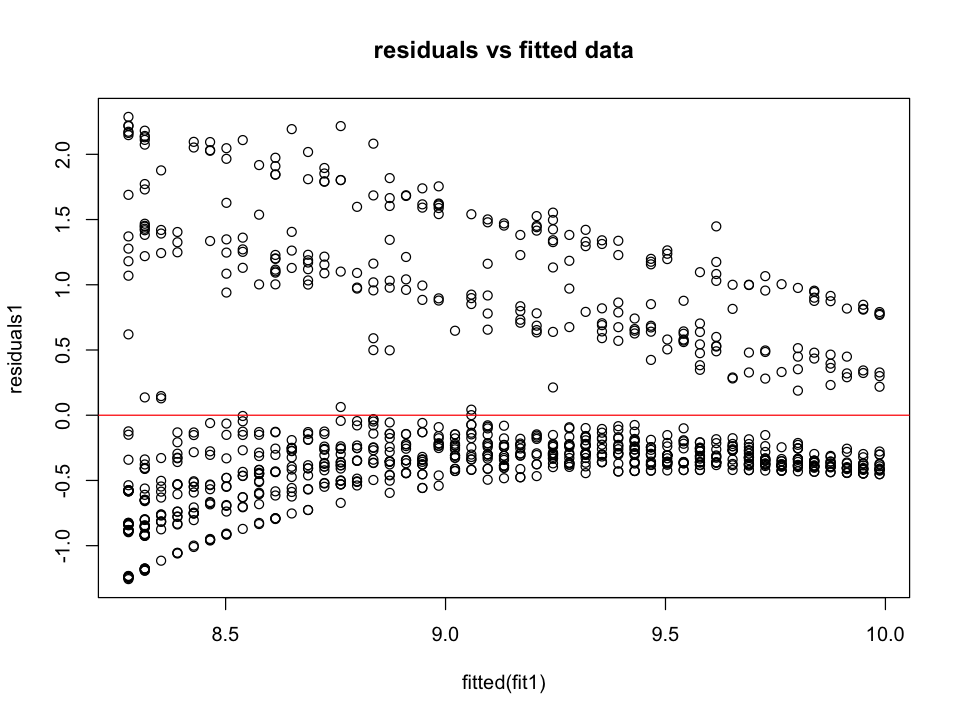

```r
options(repr.plot.width = 8, repr.plot.height = 6)
residuals1 = fit1$residuals
#produce residual vs. fitted plot
plot(fitted(fit1), residuals1, main = "residuals vs fitted data")
#add a horizontal line at 0
abline(0,0, col = "red")
```

- Residual plot fails to show equality of variance (Homoscedasticity assumption), not good!

#### 2. Test for normality using visualization

Histogram of standardize residuals

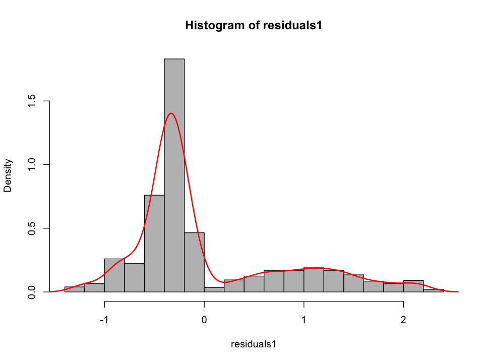

```r
hist(residuals1, breaks = 15, prob = TRUE, col = 'grey' )
lines(density(residuals1), lwd = 2, col = 'red')
```

the condition that the error terms are normally distributed is not met.

Q-Q plot of residuals

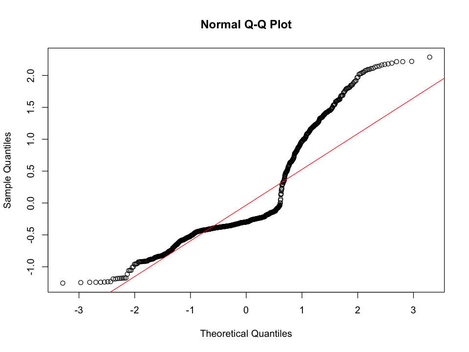

```r
#create Q-Q plot for residuals
qqnorm(residuals1)
#add a straight diagonal line to the plot
qqline(residuals1, col = "red")
```

* The relationship between the sample percentiles and theoretical percentiles is not linear. * the condition that the error terms are normally distributed is not met.

Q-Q plot of standardize residuals

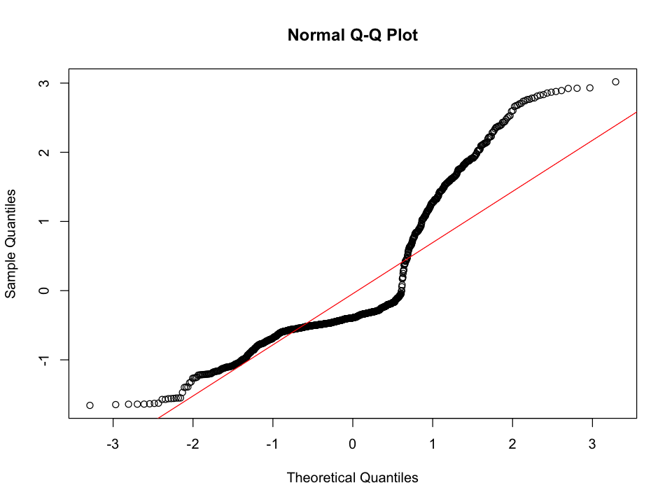

```r
res_standard = rstandard(fit1) # standardized residuals
#create Q-Q plot for residuals
qqnorm(res_standard)
#add a straight diagonal line to the plot
qqline(res_standard, col = "red")
```

#### 3. Test for normality (Shapiro-Wilk test)

Shapiro-Wilk test of normality assesses normality statistically. The null and alternative of the Shapiro-Wilk test are:

```
Null        H0: residuals are normally distributed
Alternative H1: residuals are not normally distributed
```

- a low p-value indicates that the residuals data do not follow the normal distribution.

```r
shapiro.test(residuals1) # Shapiro-Wilk test in R
```

```
	Shapiro-Wilk normality test

data:  residuals1
W = 0.83778, p-value < 2.2e-16
```

```r
shapiro.test(rstandard(fit1)) # Shapiro-Wilk test in R for standardized residuals
```

```
	Shapiro-Wilk normality test

data:  rstandard(fit1)
W = 0.83789, p-value < 2.2e-16
```

The above result shows the residuals are not normally distributed.

### Residual Analysis (Model2)

1. Scatter plot of residuals against predicted values check for patterns or heteroscedasticity (unequal variance)

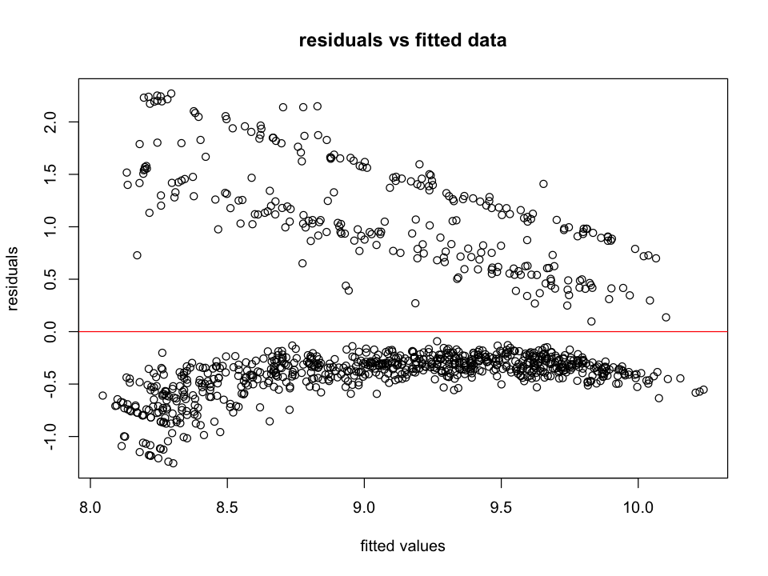

```r
#produce residual vs. fitted plot
residuals2 = resid(fit2)
plot(fitted(fit2), residuals2, xlab = 'fitted values', ylab = 'residuals', main = "residuals vs fitted data")
#add a horizontal line at 0
abline(0,0, col = "red")
```

residuals are not showing randomness, but showing some weired pattern, not good!.

1. Test for normality using visualization

Histogram of standardize residuals

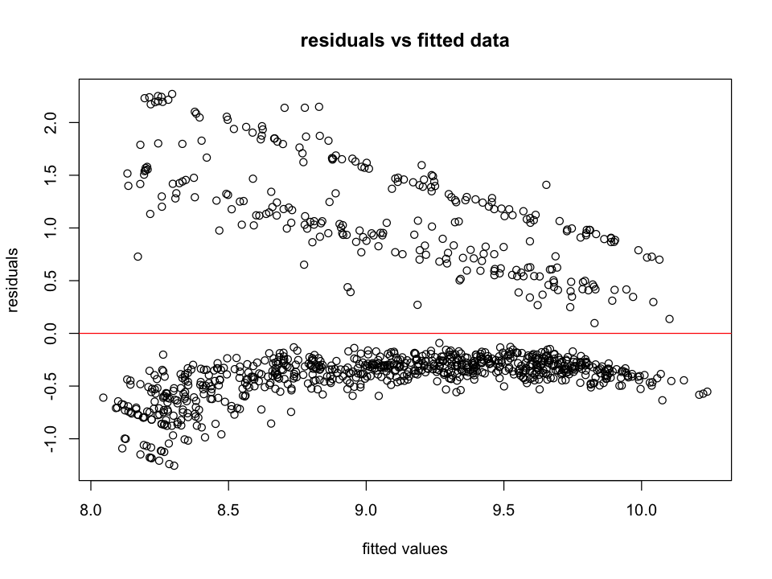

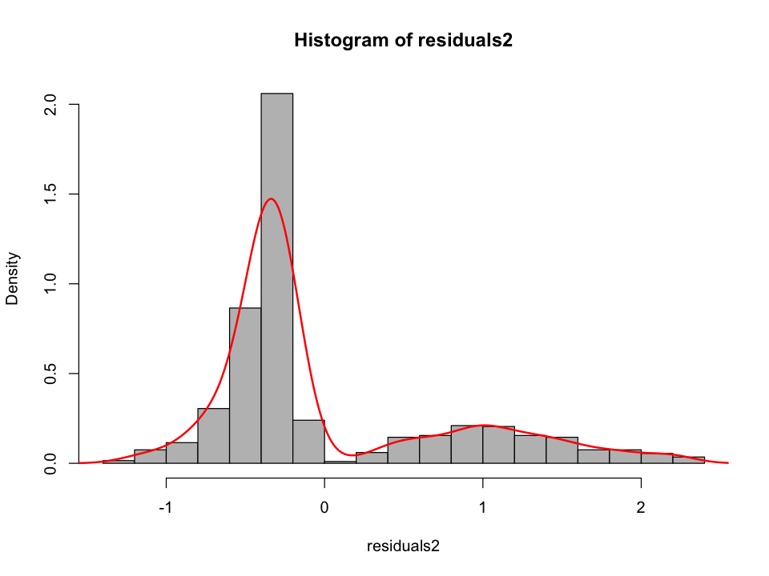

```r
#produce residual vs. fitted plot
residuals2 = resid(fit2)
plot(fitted(fit2), residuals2, xlab = 'fitted values', ylab = 'residuals', main = "residuals vs fitted data")
#add a horizontal line at 0
abline(0,0, col = "red")
hist(residuals2, breaks = 15, prob = TRUE, col = 'grey' )
lines(density(residuals2), lwd = 2, col = 'red')
```

Q-Q plot of residuals

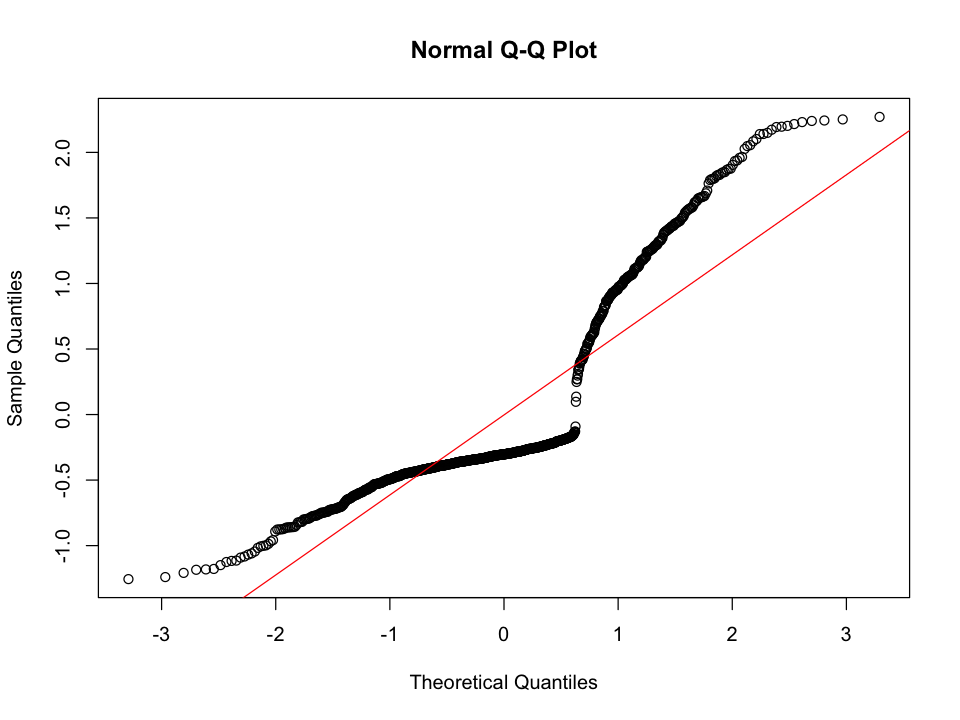

```r
#create Q-Q plot for residuals
qqnorm(residuals2)
#add a straight diagonal line to the plot
qqline(residuals2, col = "red")
```

Q-Q plot of standardize residuals2

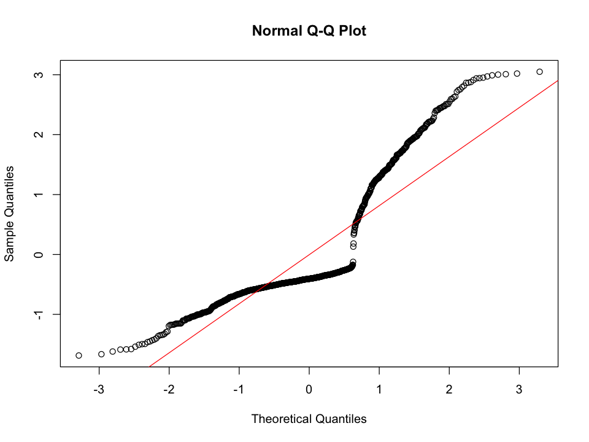

```r
res_standard = rstandard(fit2) # standardized residuals
#create Q-Q plot for residuals
qqnorm(res_standard)
#add a straight diagonal line to the plot
qqline(res_standard, col = "red")
```

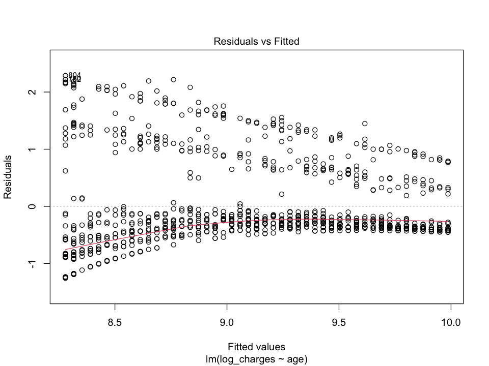

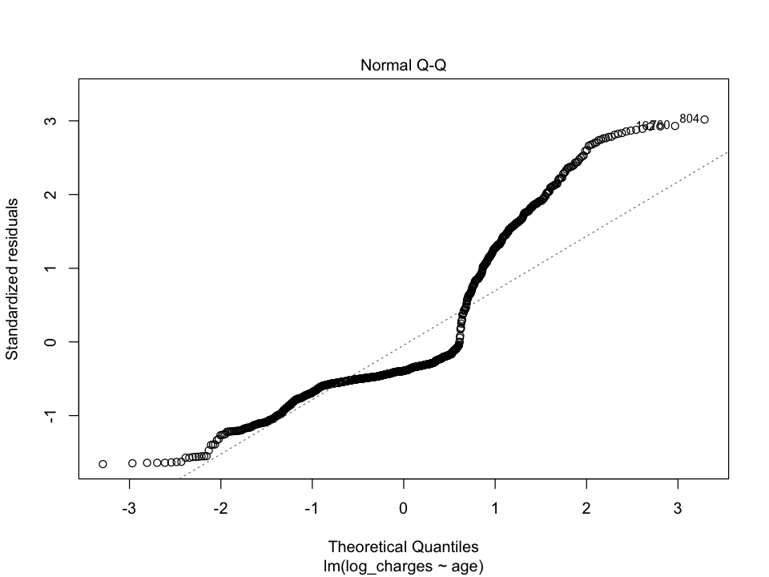

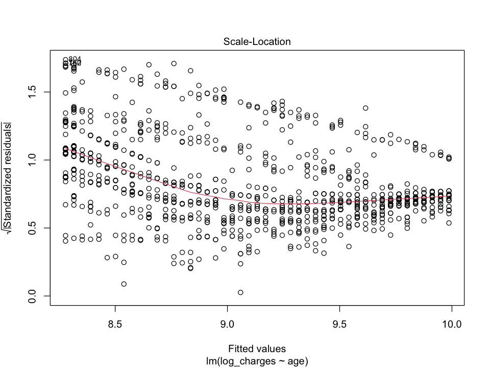

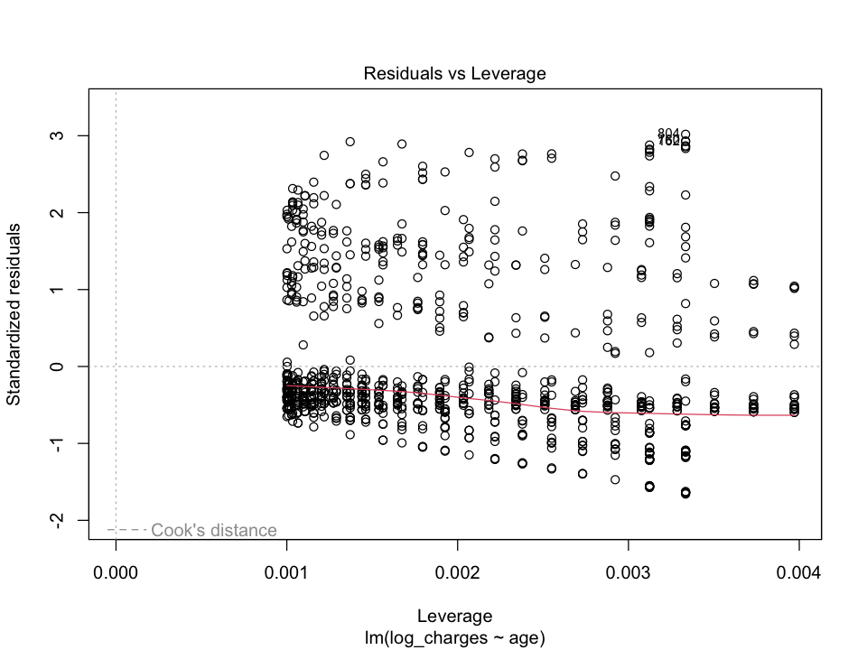

```r
plot(fit1)
```

1. Test for normality (Shapiro-Wilk test)

Shapiro-Wilk test of normality assesses normality statistically. The null and alternative of the Shapiro-Wilk test are:

```
Null        H0: residuals are normally distributed
Alternative H1: residuals are not normally distributed
```

- a low p-value indicates that the residuals data do not follow the normal distribution.

```r
shapiro.test(residuals2) # Shapiro-Wilk test in R
```

```
	Shapiro-Wilk normality test

data:  residuals2
W = 0.80638, p-value < 2.2e-16
```

residuals are not showing randomness (independent) and normality test fails, not good!.

### Evaluation Metrics for model's predictive performance

Evaluation metrics measure how good a model performs and how well it defines the relationships.

The predictability of the model can measured usinng evaluation metrics:

- MSE: Mean Squared Error $$MSE = \frac{1}{n}\sum_{i=1}^n (ŷ_i−y_i)^2$$
- MAE: Mean Absolute Error $$MAE = \frac{1}{n}\sum_{i=1}^n |ŷ_i−y_i|$$
- RMSE: Root Mean Squared Error $$RMSE = \sqrt{\frac{1}{n}\sum_{i=1}^n (ŷ_i−y_i)^2}.$$

A lower value of these metrics indicates a better model.

1. evaluation metrics for Simple Reg model (Model1)

```r
n = nrow(df)
k = 1 + 2
fit_values = fit1$fitted.values
MSE = 1/n*sum((df$log_charges - fit_values)^2)
MAE = 1/n*sum(abs(df$log_charges - fit_values))
RMSE = sqrt(1/n * sum((df$log_charges - fit_values)^2))

evaluation_metrics = c( "R-sq" = summary(fit1)$r.squared,
                       "Adj.R-sq" = summary(fit1)$adj.r.squared,
                       "log-Lik" = logLik(fit1),
                       "AIC" = AIC(fit1),
                       "BIC" = BIC(fit1),
                       "MSE" = MSE, "MAE" = MAE, "RMSE" = RMSE )
model1_eval = data.frame(model1 = round(evaluation_metrics,3))
print(model1_eval)
```

```
            model1
R-sq         0.324
Adj.R-sq     0.324
log-Lik  -1142.118
AIC       2290.236
BIC       2304.960
MSE          0.575
MAE          0.601
RMSE         0.758
```

1. evaluation metrics for MLR (Model2)

```r
n = nrow(df)
k = 3+2
fit_values = fit2$fitted.values
MSE = 1/n*sum((df$log_charges - fit_values)^2)
MAE = 1/n*sum(abs(df$log_charges - fit_values))
RMSE = sqrt(1/n * sum((df$log_charges - fit_values)^2))
evaluation_metrics = c( "R-sq" = summary(fit2)$r.squared,
                       "Adj.R-sq" = summary(fit2)$adj.r.squared,
                       "log-Lik" = logLik(fit2),
                       "AIC" = AIC(fit2),
                       "BIC" = BIC(fit2),
                       "MSE" = MSE, "MAE" = MAE, "RMSE" = RMSE )
model2_eval = data.frame(model2 = round(evaluation_metrics,3))
print(model2_eval)
```

```
            model2
R-sq         0.345
Adj.R-sq     0.343
log-Lik  -1126.266
AIC       2262.532
BIC       2287.070
MSE          0.557
MAE          0.600
RMSE         0.746
```

```r
results = data.frame(model1_eval, model2_eval)
print(results)
```

```
            model1    model2
R-sq         0.324     0.345
Adj.R-sq     0.324     0.343
log-Lik  -1142.118 -1126.266
AIC       2290.236  2262.532
BIC       2304.960  2287.070
MSE          0.575     0.557
MAE          0.601     0.600
RMSE         0.758     0.746
```

### 4. Linearity and model significance

Assessing if the relationship between predictors and the response variable is adequately captured by the linear model.

a. Plot the predictor against the response variable before modeling.

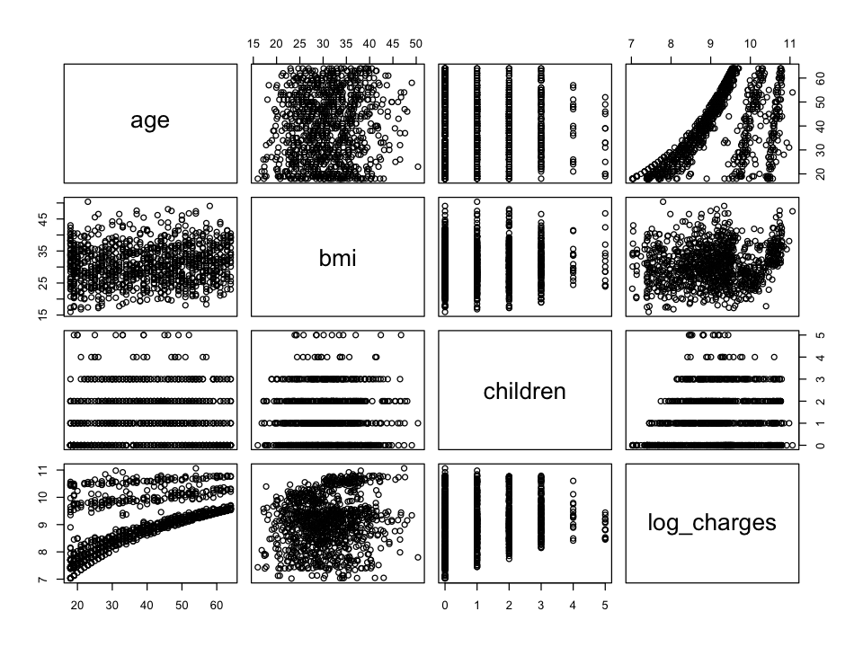

```r
# select numeric varaibles and check the linear association
df_numeric_mat = subset(df, select= c("age", "bmi", "children", "log_charges"))
plot(df_numeric_mat)
```

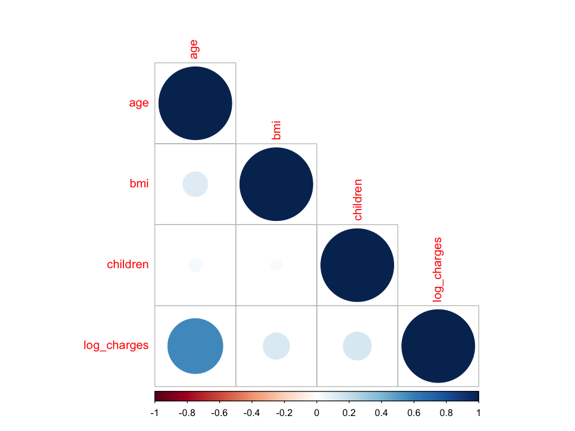

```r
# check sample correlation
#install.packages("corrplot")
library(corrplot)
corrplot(cor(df_numeric_mat),method = "circle", type = "lower")
```

b. Test overall model significane

We can assess the significance of the overall model fit using methods like the F-test or examining the p-value associated with the overall model. The corresponding test for k many predictor variable and for the model $$y = \beta_0 + \beta_1 x1 + \beta_2 x_2 + \ldots + \beta_k x_k + \epsilon$$. \begin{align*} \text{Null }H_0: \ & \beta_1 = \beta_2 = \ldots = \beta_k = 0, \text{(i.e. all predictors have no effect on y)},\\ \text{Alternative }H_1: \ & \text{at least one } \beta_j \neq 0, j = 1,2,\ldots, k, \text{(i.e. at lest one predictor has some effect on y)} \end{align*}

- The test statistic is F-score
- Low p-value indicates Linear regression model is significant.

```r
fit2 = lm(log_charges ~ age + bmi + children, data = df)
summary(fit2)
```

```
Call:
lm(formula = log_charges ~ age + bmi + children, data = df)

Residuals:
    Min      1Q  Median      3Q     Max
-1.2555 -0.4147 -0.3034  0.4091  2.2708

Coefficients:
            Estimate Std. Error t value Pr(>|t|)
(Intercept) 7.238357   0.134822  53.688  < 2e-16 ***
age         0.036384   0.001684  21.611  < 2e-16 ***
bmi         0.009514   0.003940   2.415   0.0159 *
children    0.100104   0.019750   5.069 4.78e-07 ***
---
Signif. codes:  0 ‘***’ 0.001 ‘**’ 0.01 ‘*’ 0.05 ‘.’ 0.1 ‘ ’ 1

Residual standard error: 0.7478 on 996 degrees of freedom
Multiple R-squared:  0.3453,	Adjusted R-squared:  0.3433
F-statistic: 175.1 on 3 and 996 DF,  p-value: < 2.2e-16
```

[output not shown]

The value of F-score and p-value above indicate that Regression model is significant.

c. Coefficient Estimates: Assessing the coefficients of the predictors for significance and interpreting their impact on the dependent variable.

- magnitude of the coefficient of predictor varaible shows strength of its impact on the response
- larger absolute values indicate a stronger impact or influence; however,
- if variables are on different scales, it is challenging to compare their impacts directly.
- scaling is necessary if we want compare effects directly using the coefficient terms.
- most widely used scaling methods are standardization(or normalization) and min-max transforamtion.

Usual sclaing methods are

- Centered 0: $z= (x-\mu)$
- Normalization: $z= \frac{(x-\mu)}{sd}$
- min max method: $z = \frac{(x-max)}{(max-min)}$

**Let's scale the numerical covariates**

Here we use normalization method to scale the numerical method as follows:

```r
num_covariates = subset(df, select = c("age", "bmi", "children"))
#cat_covariates = subset(df, select = c("sex", "smoker", "health_cond"))
num_std_covariates = scale(num_covariates)
new_df = df
new_df[,c("age", "bmi", "children")] = num_std_covariates
head(new_df)
```

A data.frame: 6 × 9

|  | age <dbl> | sex <chr> | bmi <dbl> | children <dbl> | smoker <chr> | region <chr> | charges <dbl> | health_cond <chr> | log_charges <dbl> |
| --- | --- | --- | --- | --- | --- | --- | --- | --- | --- |
| 1 | -1.4564882 | female | -0.4900222 | -0.90092736 | yes | southwest | 16884.924 | high | 9.734176 |
| 2 | -1.5271401 | male | 0.4806364 | -0.06673536 | no | southeast | 1725.552 | low | 7.453302 |
| 3 | -0.8206214 | male | 0.3533098 | 1.60164864 | no | southeast | 4449.462 | low | 8.400538 |
| 4 | -0.4673621 | male | -1.3490633 | -0.90092736 | no | northwest | 21984.471 | high | 9.998092 |
| 5 | -0.5380140 | male | -0.3279702 | -0.90092736 | no | northwest | 3866.855 | low | 8.260197 |
| 6 | -0.6086658 | female | -0.8471981 | -0.90092736 | no | southeast | 3756.622 | low | 8.231275 |

```r
fit3 = lm(log_charges ~  age + bmi + children, data = new_df)
summary(fit3)
```

```
Call:
lm(formula = log_charges ~ age + bmi + children, data = new_df)

Residuals:
    Min      1Q  Median      3Q     Max
-1.2555 -0.4147 -0.3034  0.4091  2.2708

Coefficients:
            Estimate Std. Error t value Pr(>|t|)
(Intercept)  9.08146    0.02365 384.053  < 2e-16 ***
age          0.51497    0.02383  21.611  < 2e-16 ***
bmi          0.05754    0.02383   2.415   0.0159 *
children     0.12000    0.02368   5.069 4.78e-07 ***
---
Signif. codes:  0 ‘***’ 0.001 ‘**’ 0.01 ‘*’ 0.05 ‘.’ 0.1 ‘ ’ 1

Residual standard error: 0.7478 on 996 degrees of freedom
Multiple R-squared:  0.3453,	Adjusted R-squared:  0.3433
F-statistic: 175.1 on 3 and 996 DF,  p-value: < 2.2e-16
```

```r
fit_values = fit3$fitted.values
MSE = 1/n*sum((df$log_charges - fit_values)^2)
MAE = 1/n*sum(abs(df$log_charges - fit_values))
RMSE = sqrt(1/n * sum((df$log_charges - fit_values)^2))

evaluation_metrics = c( "R-sq" =  summary(fit3)$r.square,
                        "Adj.R-sq" =  summary(fit3)$adj.r.square,
                       "log-Lik" = logLik(fit3),
                       "AIC" = AIC(fit3),
                       "BIC" = BIC(fit3), "MSE" = MSE,
                       "MAE" = MAE, "RMSE" = RMSE )
model3_eval = data.frame(model3 = round(evaluation_metrics,3))
print(model3_eval)
```

```
            model3
R-sq         0.345
Adj.R-sq     0.343
log-Lik  -1126.266
AIC       2262.532
BIC       2287.070
MSE          0.557
MAE          0.600
RMSE         0.746
```

```r
results = data.frame(model1_eval, model2_eval,model3_eval)
print(results)
```

```
            model1    model2    model3
R-sq         0.324     0.345     0.345
Adj.R-sq     0.324     0.343     0.343
log-Lik  -1142.118 -1126.266 -1126.266
AIC       2290.236  2262.532  2262.532
BIC       2304.960  2287.070  2287.070
MSE          0.575     0.557     0.557
MAE          0.601     0.600     0.600
RMSE         0.758     0.746     0.746
```

Scaling of covariates (independent variables) is often needed in multiple linear regression (MLR) for several reasons:

- Magnitude Differences: When the variables in your dataset have different scales, the coefficients of the regression model may be biased towards variables with larger scales. Scaling helps to ensure that all variables contribute equally to the regression model.
- Gradient Descent Optimization: If you're using optimization algorithms such as gradient descent to estimate the coefficients of the regression model, scaling can help speed up convergence. Variables with larger scales can dominate the optimization process, causing it to take longer to converge.
- Interpretability: Scaling does not affect the relationship between variables, but it does affect the interpretation of the coefficients. When variables are on different scales, the coefficients represent the change in the dependent variable for a one-unit change in the predictor. Scaling ensures that these coefficients are comparable.
- Regularization Techniques: Regularization techniques like Ridge regression and Lasso regression penalize the size of the coefficients. Scaling ensures that all variables are penalized equally, regardless of their scales.

However, there are some cases where scaling may not be necessary or may not have a significant impact:

- Categorical Variables: If your dataset contains categorical variables (e.g., gender, region), scaling may not be necessary as these variables do not have a scale.
- Regularization with Interaction Terms: If you're including interaction terms or polynomial terms in your regression model along with regularization, the need for scaling may vary depending on the specific context.
- Tree-based Models: Decision trees and ensemble methods like Random Forests and Gradient Boosting Machines are not affected by the scale of the features.

In summary, while scaling is not always necessary in MLR, it can often improve model performance, convergence, and interpretability, especially when dealing with variables with different scales.

d. Test for significance of predictor: Test whether the predictor variable is statistically significant or not in predicting the response varaible

- not all the predictor varaibles in MLR will be equally important in explaining y.
- there might be some varaibles which have no significant effect on y.
- these can be assessed from the scatter plot of response y vs predictor varaible $X_j$.
- the statistical method of testing for the significance of such varaible $X_j$ can be defined as

\begin{align*} \text{Null }H_0: \ & \beta_j = 0,\; X_j \text{ has no effect on y},\\ \text{Alternative }H_1: \ & \beta_j \neq 0, X_j \; \text{has some effect on y} \end{align*}

- The test statistic is t-score
- Low p-value indicates variable $X_j$ is significant.

**Removing insignificant varaible from the model**

- less significant variables in the models are variables that have high p-value (usual cutoff is 0.05)
- remove one varaible that has highest p-value, then run the model using rest of the value and check p-values
- if you still find high p-value, remove the varible one at a time until you come to the predefined cutoff.

#### Variable selection methods

Variable selection methods in regression analysis help in identifying the most relevant predictors to include in a model. Here are some common techniques:

- Forward Selection: Starts with an empty model and iteratively adds variables that improve model fit based on a chosen criterion (e.g., p-values, AIC, BIC) until a stopping rule is met.
- Backward Elimination: Begins with a model containing all predictors and iteratively removes the least significant variable based on a chosen criterion until a stopping rule is met.
- Stepwise Selection: Combines forward and backward selection, adding or removing variables at each step based on a chosen criterion until the best subset of variables is identified.
- Lasso Regression (L1 Regularization): Uses regularization to penalize coefficients, effectively shrinking some coefficients to zero, thus performing variable selection automatically by excluding less influential predictors.
- Ridge Regression (L2 Regularization): Similar to Lasso but doesn't set coefficients to exactly zero, reducing the impact of less important predictors rather than entirely excluding them.
- Elastic Net: Combines Lasso and Ridge regularization techniques to benefit from both variable selection (like Lasso) and handling correlated predictors (like Ridge).

### What other factors can affect the model's predictibility?

The predictability of a regression model refers to its ability to accurately forecast or estimate outcomes based on input data. Several factors affect a model's predictability:

- Quality of Data: Clean, relevant, and representative data usually leads to better predictions. If the data is noisy, incomplete, or biased, it can affect the model's performance.
- Model Complexity: The complexity of the model matters. A too simple model may not capture all the patterns in the data, while an overly complex model might overfit (perform well on training data but poorly on new data).
- Feature Selection: Choosing the right features (variables) for the model is crucial. Irrelevant or redundant features can negatively impact predictability.
- Training Size: Having a sufficient amount of data for training is essential. More data often leads to better model performance, allowing it to generalize well to unseen data.
- Model Evaluation: Using appropriate evaluation metrics helps assess how well the model is performing. Metrics like Mean Squared Error (MSE), R-squared, or Root Mean Squared Error (RMSE) help measure prediction accuracy.
- Assumptions: Regression models rely on certain assumptions about the data. Violations of these assumptions can affect predictability. For instance, if the relationship between variables is non-linear but a linear model is used, predictability might be compromised.
- Regularization Techniques: Applying regularization techniques (like Lasso, Ridge regression) can help prevent overfitting, enhancing a model's generalizability.
- Cross-Validation: Utilizing techniques like k-fold cross-validation aids in assessing how the model performs on different subsets of the data, helping to gauge its reliability.

Remember, no model is perfect, and there's always a trade-off between bias and variance. Ensuring a balance between the two is key to improving the predictability of a regression model. Additionally, the context of the problem and the domain expertise play a significant role in determining whether the model's predictions are practically useful.

## Regression model with categorical Covariates

```r
tb = table(df$sex, df$smoker)
tb
```

```
          no yes
  female 414  81
  male   390 115
```

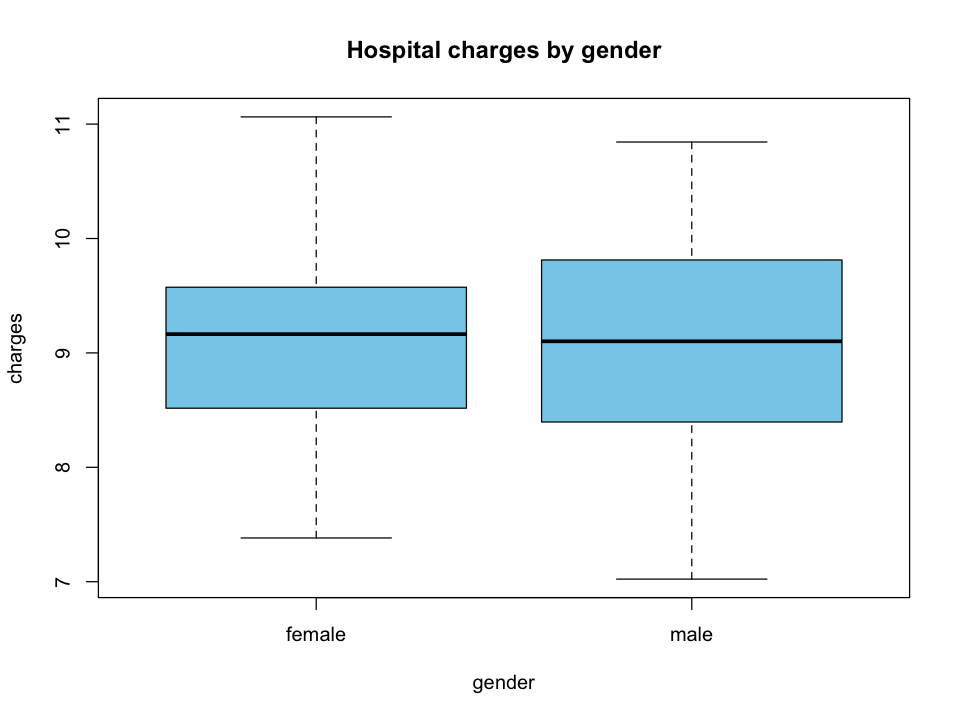

```r
boxplot(df$log_charges~df$sex, col="skyblue",
        main='Hospital charges by gender',
        xlab="gender", ylab="charges")
```

```r
t.test(log_charges~sex, data = df)
```

```
	Welch Two Sample t-test

data:  log_charges by sex
t = 0.59852, df = 976.39, p-value = 0.5496
alternative hypothesis: true difference in means between group female and group male is not equal to 0
95 percent confidence interval:
 -0.07949215  0.14926010
sample estimates:
mean in group female   mean in group male
            9.099078             9.064194
```

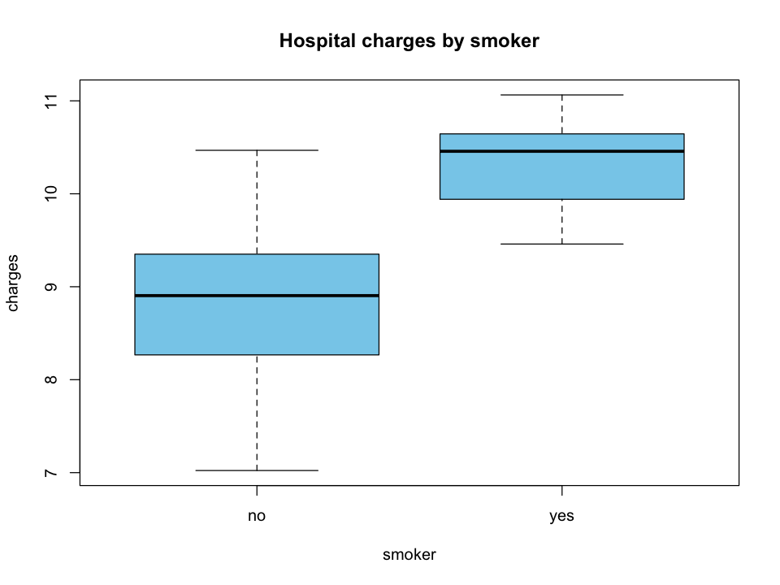

```r
boxplot(df$log_charges~df$smoker, col="skyblue",
        main='Hospital charges by smoker',
        xlab="smoker", ylab="charges")
```

- t-test suggests that the effect of gender on the log-hospital charge is not significant, it implies that there is no statistically significant difference in log-hospital charges between different genders.
- In such cases, including the gender variable in the regression model may not be meaningful or necessary.

```r
t.test(log_charges~smoker, data = df)
```

```
	Welch Two Sample t-test

data:  log_charges by smoker
t = -39.573, df = 592.84, p-value < 2.2e-16
alternative hypothesis: true difference in means between group no and group yes is not equal to 0
95 percent confidence interval:
 -1.598141 -1.447011
sample estimates:
 mean in group no mean in group yes
         8.783037         10.305613
```

- t-test suggests that the effect of smoker on the log-hospital charge is significant,
- In such cases, including the smoker variable in the regression model is meaningful.

**Check interaction between gender and smokers**

```r
aov1 = aov(log_charges ~  sex*smoker, data = df)
summary(aov1)
```

```
             Df Sum Sq Mean Sq F value Pr(>F)
sex           1    0.3     0.3   0.633 0.4265
smoker        1  369.4   369.4 768.627 <2e-16 ***
sex:smoker    1    2.2     2.2   4.567 0.0328 *
Residuals   996  478.7     0.5
---
Signif. codes:  0 ‘***’ 0.001 ‘**’ 0.01 ‘*’ 0.05 ‘.’ 0.1 ‘ ’ 1
```

- interaction between gender and smokers is significant for significance level ($\alpha$ = 0.05).
- including the interaction term in regression model might be meaningful

```r
tb = table(df$sex,df$health_cond)
tb
```

```
         high low med
  female  146 185 164
  male    164 199 142
```

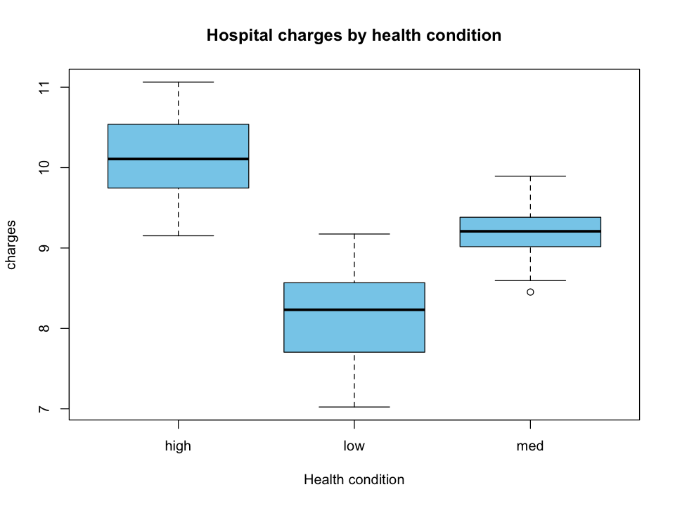

```r
boxplot(df$log_charges~df$health_cond, col="skyblue",
        main='Hospital charges by health condition',
        xlab="Health condition", ylab="charges")
```

```r
anova_health = aov(log_charges ~ health_cond, data = df)
summary(anova_health)
```

```
             Df Sum Sq Mean Sq F value Pr(>F)
health_cond   2  657.4   328.7    1696 <2e-16 ***
Residuals   997  193.2     0.2
---
Signif. codes:  0 ‘***’ 0.001 ‘**’ 0.01 ‘*’ 0.05 ‘.’ 0.1 ‘ ’ 1
```

- ANOVA-test suggests that the effect of *health condition* on the log-hospital charge is significant,
- In such cases, including the *health condition* variable in the regression model is meaningful.

## Model building using categorical Covariates

```r
#Manually create indicator (or dummy) variables
Sex_male = as.numeric(new_df$sex == "male")
Smoker_yes = as.numeric(new_df$smoker == "yes")
sex.smoker =  as.numeric(new_df$sex == "male" & df$smoker == "yes")
Health_low =  as.numeric(df$health_cond == "low")
Health_med =  as.numeric(df$health_cond == "med")
dummy_df = cbind(num_std_covariates, Sex_male,Smoker_yes, Health_low,Health_med, sex.smoker,log_charges = df$log_charges) # all covariates including indicator variable
dummy_df = data.frame(dummy_df)
head(dummy_df)
```

A data.frame: 6 × 9

|  | age <dbl> | bmi <dbl> | children <dbl> | Sex_male <dbl> | Smoker_yes <dbl> | Health_low <dbl> | Health_med <dbl> | sex.smoker <dbl> | log_charges <dbl> |
| --- | --- | --- | --- | --- | --- | --- | --- | --- | --- |
| 1 | -1.4564882 | -0.4900222 | -0.90092736 | 0 | 1 | 0 | 0 | 0 | 9.734176 |
| 2 | -1.5271401 | 0.4806364 | -0.06673536 | 1 | 0 | 1 | 0 | 0 | 7.453302 |
| 3 | -0.8206214 | 0.3533098 | 1.60164864 | 1 | 0 | 1 | 0 | 0 | 8.400538 |
| 4 | -0.4673621 | -1.3490633 | -0.90092736 | 1 | 0 | 0 | 0 | 0 | 9.998092 |
| 5 | -0.5380140 | -0.3279702 | -0.90092736 | 1 | 0 | 1 | 0 | 0 | 8.260197 |
| 6 | -0.6086658 | -0.8471981 | -0.90092736 | 0 | 0 | 1 | 0 | 0 | 8.231275 |

```r
fit4 = lm(log_charges ~ ., data = dummy_df)
summary(fit4)
```

```
Call:
lm(formula = log_charges ~ ., data = dummy_df)

Residuals:
    Min      1Q  Median      3Q     Max
-0.8478 -0.2195  0.0220  0.2103  1.1649

Coefficients:
            Estimate Std. Error t value Pr(>|t|)
(Intercept)  9.57299    0.03323 288.050  < 2e-16 ***
age          0.27884    0.01457  19.135  < 2e-16 ***
bmi         -0.03716    0.01119  -3.321 0.000931 ***
children     0.10117    0.01050   9.633  < 2e-16 ***
Sex_male    -0.08735    0.02330  -3.749 0.000188 ***
Smoker_yes   0.78299    0.04744  16.504  < 2e-16 ***
Health_low  -1.14518    0.04307 -26.588  < 2e-16 ***
Health_med  -0.56166    0.03324 -16.899  < 2e-16 ***
sex.smoker   0.09337    0.05339   1.749 0.080611 .
---
Signif. codes:  0 ‘***’ 0.001 ‘**’ 0.01 ‘*’ 0.05 ‘.’ 0.1 ‘ ’ 1

Residual standard error: 0.3293 on 991 degrees of freedom
Multiple R-squared:  0.8737,	Adjusted R-squared:  0.8726
F-statistic: 856.7 on 8 and 991 DF,  p-value: < 2.2e-16
```

```r
fit4 = lm(log_charges~ age + bmi+ children +  sex + smoker + sex*smoker+  health_cond, data = new_df)
summary(fit4)
```

```
Call:
lm(formula = log_charges ~ age + bmi + children + sex + smoker +
    sex * smoker + health_cond, data = new_df)

Residuals:
    Min      1Q  Median      3Q     Max
-0.8478 -0.2195  0.0220  0.2103  1.1649

Coefficients:
                  Estimate Std. Error t value Pr(>|t|)
(Intercept)        9.57299    0.03323 288.050  < 2e-16 ***
age                0.27884    0.01457  19.135  < 2e-16 ***
bmi               -0.03716    0.01119  -3.321 0.000931 ***
children           0.10117    0.01050   9.633  < 2e-16 ***
sexmale           -0.08735    0.02330  -3.749 0.000188 ***
smokeryes          0.78299    0.04744  16.504  < 2e-16 ***
health_condlow    -1.14518    0.04307 -26.588  < 2e-16 ***
health_condmed    -0.56166    0.03324 -16.899  < 2e-16 ***
sexmale:smokeryes  0.09337    0.05339   1.749 0.080611 .
---
Signif. codes:  0 ‘***’ 0.001 ‘**’ 0.01 ‘*’ 0.05 ‘.’ 0.1 ‘ ’ 1

Residual standard error: 0.3293 on 991 degrees of freedom
Multiple R-squared:  0.8737,	Adjusted R-squared:  0.8726
F-statistic: 856.7 on 8 and 991 DF,  p-value: < 2.2e-16
```

The interaction term seems to be insignificant, we fit a model after removing it.

```r
fit4 = lm(log_charges~ age + bmi+ children +  sex + smoker + health_cond, data = new_df)
summary(fit4)
```

```
Call:
lm(formula = log_charges ~ age + bmi + children + sex + smoker +
    health_cond, data = new_df)

Residuals:
     Min       1Q   Median       3Q      Max
-0.85564 -0.21042  0.01992  0.20762  1.15133

Coefficients:
               Estimate Std. Error t value Pr(>|t|)
(Intercept)     9.56781    0.03314 288.744  < 2e-16 ***
age             0.27830    0.01458  19.082  < 2e-16 ***
bmi            -0.03683    0.01120  -3.287 0.001046 **
children        0.10217    0.01050   9.733  < 2e-16 ***
sexmale        -0.06950    0.02097  -3.314 0.000951 ***
smokeryes       0.83285    0.03796  21.942  < 2e-16 ***
health_condlow -1.14947    0.04305 -26.703  < 2e-16 ***
health_condmed -0.56565    0.03319 -17.042  < 2e-16 ***
---
Signif. codes:  0 ‘***’ 0.001 ‘**’ 0.01 ‘*’ 0.05 ‘.’ 0.1 ‘ ’ 1

Residual standard error: 0.3296 on 992 degrees of freedom
Multiple R-squared:  0.8733,	Adjusted R-squared:  0.8724
F-statistic: 976.6 on 7 and 992 DF,  p-value: < 2.2e-16
```

All other covariates in the above model are statistically significant.

```r
logLik(fit4)
```

```
'log Lik.' -305.1729 (df=9)
```

```r
summary(fit4)$adj.r.squared
```

0.872384181562898

#### Interpretation of coefficient of categorical covaraites

```r
n = nrow(df)
k = 8 + 2 # 8 covariates, 1 intercept and 1 variance parameter
fit_values = fit4$fitted.values
MSE = 1/n*sum((df$log_charges - fit_values)^2)
MAE = 1/n*sum(abs(df$log_charges - fit_values))
RMSE = sqrt(1/n * sum((df$log_charges - fit_values)^2))
evaluation_metrics = c("R-sq" =  summary(fit4)$r.square,
                        "Adj.R-sq" =  summary(fit4)$adj.r.square,
                       "log-Lik" = logLik(fit4), "AIC" = AIC(fit4),
                       "BIC" =BIC(fit4), "MSE" = MSE,
                       "MAE" = MAE, "RMSE" = RMSE )
model4_eval = data.frame(model4 = round(evaluation_metrics,3))
print(model4_eval)
```

```
           model4
R-sq        0.873
Adj.R-sq    0.872
log-Lik  -305.173
AIC       628.346
BIC       672.516
MSE         0.108
MAE         0.262
RMSE        0.328
```

```r
results = data.frame(model1_eval, model2_eval,model3_eval, model4_eval)
knitr::kable(results, "simple")
```

```
               model1      model2      model3     model4
---------  ----------  ----------  ----------  ---------
R-sq            0.324       0.345       0.345      0.873
Adj.R-sq        0.324       0.343       0.343      0.872
log-Lik     -1142.118   -1126.266   -1126.266   -305.173
AIC          2290.236    2262.532    2262.532    628.346
BIC          2304.960    2287.070    2287.070    672.516
MSE             0.575       0.557       0.557      0.108
MAE             0.601       0.600       0.600      0.262
RMSE            0.758       0.746       0.746      0.328
```

### Residual Analysis (Model4)

1. Scatter plot of residuals against predicted values check for patterns or heteroscedasticity (unequal variance)

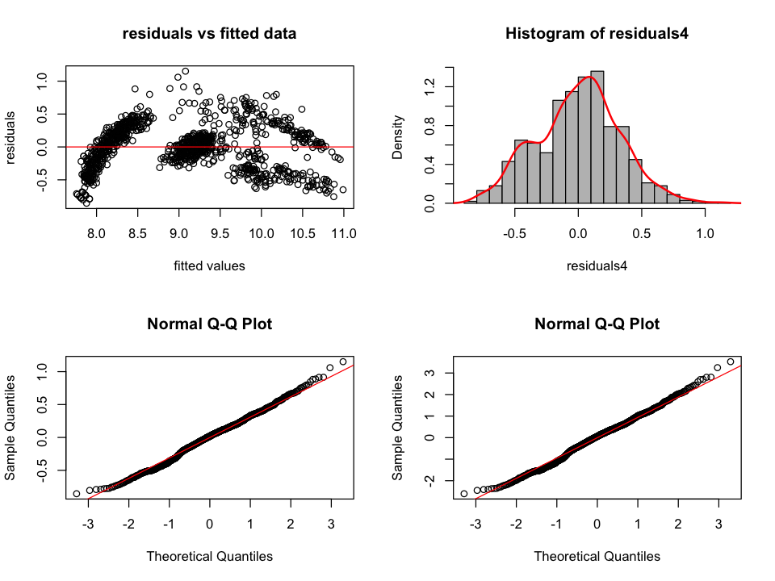

```r
par(mfrow = c(2, 2))
#produce residual vs. fitted plot
residuals4 = resid(fit4)
plot(fitted(fit4), residuals4, xlab = 'fitted values', ylab = 'residuals', main = "residuals vs fitted data")
#add a horizontal line at 0
abline(0,0, col = "red")
hist(residuals4, breaks = 15, prob = TRUE, col = 'grey' )
lines(density(residuals4), lwd = 2, col = 'red')
#create Q-Q plot for residuals
qqnorm(residuals4)
#add a straight diagonal line to the plot
qqline(residuals4, col = "red")

res_standard = rstandard(fit4) # standardized residuals
#create Q-Q plot for residuals
qqnorm(res_standard)
#add a straight diagonal line to the plot
qqline(res_standard, col = "red")
```

```r
shapiro.test(residuals4) # Shapiro-Wilk test in R
```

```
	Shapiro-Wilk normality test

data:  residuals4
W = 0.99518, p-value = 0.002967
```

#### Prediction at new data

We have $$\hat y = \beta_0 1+ \beta_1 X_1+ \ldots+ \beta_p X_p,$$ where $X = [1, X_1, X_2,\ldots, X_p]$ is matrix of p covaraites (predictors).

Let $[\hat\beta_0, \hat\beta_1, \ldots, \hat\beta_p]$ be the estimated values for set of parameters. Then, for any given covaraites $X^{new} = [1, X_1, X_2,\ldots, X_p]$ we have

$$ \hat y_{new} = \beta_0 1+ \beta_1 X^{new}_1+ \ldots+ \beta_p X^{new}_p. $$

### Test the model predictibility for the new data

```r
test_data = read.csv("~/Desktop/STAT4101L_all_files/test_insurance.csv", header = TRUE)
head(test_data)
```

A data.frame: 6 × 8

|  | age <int> | sex <chr> | bmi <dbl> | children <int> | smoker <chr> | region <chr> | charges <dbl> | health_cond <chr> |
| --- | --- | --- | --- | --- | --- | --- | --- | --- |
| 1 | 30 | male | 22.99 | 2 | yes | northwest | 17361.766 | med |
| 2 | 24 | male | 32.70 | 0 | yes | southwest | 34472.841 | high |
| 3 | 24 | male | 25.80 | 0 | no | southwest | 1972.950 | low |
| 4 | 48 | male | 29.60 | 0 | no | southwest | 21232.182 | high |
| 5 | 47 | male | 19.19 | 1 | no | northeast | 8627.541 | low |
| 6 | 29 | male | 31.73 | 2 | no | northwest | 4433.388 | low |

```r
test_num_covariates = subset(test_data, select = c("age", "bmi", "children"))
test_cat_covariates = subset(test_data, select = c("sex", "smoker", "health_cond"))
```

- If we trained the model with scaled (or standardized) covarites, then we should scale the test covariates with same scaling method
- Model1 and model2 are built without scaling, and model3 is built with scaled numerical covariates.

#### Prediction using model

```
predict(model, newdata)
```

```r
test_cov = subset(test_data, select = c("age", "bmi", "children", "sex", "smoker", "health_cond"))
test_response = log(test_data$charges)
t = length(test_response)
t
```

338

#### Model1 (Simple linear regression model with age as a covariate)

$y = \beta_0 + \beta_1 \; age$

```r
predict_y = predict(fit1, test_cov)
```

```r
Test_MSE = 1/t*sum((test_response  - predict_y)^2)
Test_MAE = 1/t*sum(abs(test_response  - predict_y))
Test_RMSE = sqrt(1/t * sum((test_response  - predict_y)^2))
pred_measure = c("Test MSE" = Test_MSE, "Test MAE" = Test_MAE, "Test RMSE" = Test_RMSE)
model1_pred = data.frame(model1 = round(pred_measure,4))
model1_pred
```

A data.frame: 3 × 1

|  | model1 <dbl> |
| --- | --- |
| Test MSE | 0.7213 |
| Test MAE | 0.6671 |
| Test RMSE | 0.8493 |

#### Model2 (Full model without scaled covaraites)

$y= \beta_0 + \beta_1 \;age + \beta_2 \; bmi + \beta_3 \;children$

```r
predict_y = predict(fit2, test_cov)
```

```r
Test_MSE = 1/t*sum((test_response  - predict_y)^2)
Test_MAE = 1/t*sum(abs(test_response  - predict_y))
Test_RMSE = sqrt(1/t * sum((test_response  - predict_y)^2))
pred_measure = c("Test MSE" = Test_MSE, "Test MAE" = Test_MAE, "Test RMSE" = Test_RMSE)
model2_pred = data.frame(model2 = round(pred_measure,4))
model2_pred
```

A data.frame: 3 × 1

|  | model2 <dbl> |
| --- | --- |
| Test MSE | 0.6923 |
| Test MAE | 0.6521 |
| Test RMSE | 0.8320 |

#### Model3 (Model with scaled numerical covariates)

$y= \beta_0 + \beta_1 \;age + \beta_2 \; bmi + \beta_3 \;children$

- normalization: $x_{normalize} = \frac{x-mean}{sd}$, we can use R-function scale for the training data
- Test data should be normalized by using the same center and scale of train data.

```r
train_cov = subset(df, select = c("age", "bmi", "children")) # numerical covariates of training data
for (j in 1:ncol(train_cov)){
    train_meanj = mean(train_cov[,j])
    train_sdj = sd(train_cov[,j])
    test_cov[, j] = (test_cov[,j] - train_meanj)/train_sdj
}
head(test_cov)
```

A data.frame: 6 × 6

|  | age <dbl> | bmi <dbl> | children <dbl> | sex <chr> | smoker <chr> | health_cond <chr> |
| --- | --- | --- | --- | --- | --- | --- |
| 1 | -0.6793177 | -1.3019359 | 0.76745664 | male | yes | med |
| 2 | -1.1032289 | 0.3037020 | -0.90092736 | male | yes | high |
| 3 | -1.1032289 | -0.8372765 | -0.90092736 | male | no | low |
| 4 | 0.5924159 | -0.2089115 | -0.90092736 | male | no | high |
| 5 | 0.5217640 | -1.9303009 | -0.06673536 | male | no | low |
| 6 | -0.7499696 | 0.1433036 | 0.76745664 | male | no | low |

```r
#summary(fit3)
beta_vec = fit3$coefficients
round(beta_vec,4)
```

**(Intercept)**

9.0815

**age**

0.515

**bmi**

0.0575

**children**

0.12

```r
predict_y =  predict(fit3, test_cov)
```

```r
Test_MSE = 1/t*sum((test_response  - predict_y)^2)
Test_MAE = 1/t*sum(abs(test_response  - predict_y))
Test_RMSE = sqrt(1/t * sum((test_response  - predict_y)^2))
pred_measure = c("Test MSE" = Test_MSE, "Test MAE" = Test_MAE, "Test RMSE" = Test_RMSE)
model3_pred = data.frame(model3 = round(pred_measure,4))
model3_pred
```

A data.frame: 3 × 1

|  | model3 <dbl> |
| --- | --- |
| Test MSE | 0.6923 |
| Test MAE | 0.6521 |
| Test RMSE | 0.8320 |

#### Model4 (Model with numerical covariates and categorical covariates)

```r
beta_vec = fit4$coefficients
round(beta_vec,3)
```

**(Intercept)**

9.568

**age**

0.278

**bmi**

-0.037

**children**

0.102

**sexmale**

-0.069

**smokeryes**

0.833

**health_condlow**

-1.149

**health_condmed**

-0.566

```r
predict_y = predict(fit4, test_cov)
```

```r
Test_MSE = 1/t*sum((test_response  - predict_y)^2)
Test_MAE = 1/t*sum(abs(test_response  - predict_y))
Test_RMSE = sqrt(1/t * sum((test_response  - predict_y)^2))
pred_measure = c("Test MSE" = Test_MSE, "Test MAE" = Test_MAE, "Test RMSE" = Test_RMSE)
model4_pred = data.frame(model4 = round(pred_measure,4))
model4_pred
```

A data.frame: 3 × 1

|  | model4 <dbl> |
| --- | --- |
| Test MSE | 0.1197 |
| Test MAE | 0.2731 |
| Test RMSE | 0.3459 |

```r
pred_results = data.frame(model1_pred, model2_pred,model3_pred,model4_pred)
pred_results
```

A data.frame: 3 × 4

|  | model1 <dbl> | model2 <dbl> | model3 <dbl> | model4 <dbl> |
| --- | --- | --- | --- | --- |
| Test MSE | 0.7213 | 0.6923 | 0.6923 | 0.1197 |
| Test MAE | 0.6671 | 0.6521 | 0.6521 | 0.2731 |
| Test RMSE | 0.8493 | 0.8320 | 0.8320 | 0.3459 |

```r
train_test_results = rbind(results , pred_results)
train_test_results
```

A data.frame: 11 × 4

|  | model1 <dbl> | model2 <dbl> | model3 <dbl> | model4 <dbl> |
| --- | --- | --- | --- | --- |
| R-sq | 0.3240 | 0.3450 | 0.3450 | 0.8730 |
| Adj.R-sq | 0.3240 | 0.3430 | 0.3430 | 0.8720 |
| log-Lik | -1142.1180 | -1126.2660 | -1126.2660 | -305.1730 |
| AIC | 2290.2360 | 2262.5320 | 2262.5320 | 628.3460 |
| BIC | 2304.9600 | 2287.0700 | 2287.0700 | 672.5160 |
| MSE | 0.5750 | 0.5570 | 0.5570 | 0.1080 |
| MAE | 0.6010 | 0.6000 | 0.6000 | 0.2620 |
| RMSE | 0.7580 | 0.7460 | 0.7460 | 0.3280 |
| Test MSE | 0.7213 | 0.6923 | 0.6923 | 0.1197 |
| Test MAE | 0.6671 | 0.6521 | 0.6521 | 0.2731 |
| Test RMSE | 0.8493 | 0.8320 | 0.8320 | 0.3459 |

- model2 and model3 are same except considering the scaling of numerical covaraites
- scaling makes easier to compare the effects of predictors on response
- All the predictor variables in model2/model4 are significant

#### Prediction interval and corresponding plot

See [the link](https://www.stat.uchicago.edu/~yibi/teaching/stat224/L04.pdf), for more details.

- $(1-\alpha)100\%$ Confidence interval of new predicted values = $\hat{y_h} \pm t_{\frac{\alpha}{2},n-(k+1)}*\text{SE}(\hat{y_h})$

```r
predict_output = predict(fit4, test_cov, se.fit=TRUE, interval="prediction", level=0.95)
head(predict_output$fit)
```

A matrix: 6 × 3 of type dbl

|  | fit | lwr | upr |
| --- | --- | --- | --- |
| 1 | 9.702814 | 9.051131 | 10.354497 |
| 2 | 9.920901 | 9.271048 | 10.570755 |
| 3 | 7.980596 | 7.332153 | 8.629038 |
| 4 | 9.578822 | 8.928554 | 10.229090 |
| 5 | 8.558308 | 7.908377 | 9.208240 |
| 6 | 8.213253 | 7.564926 | 8.861580 |

#### Prediction plot

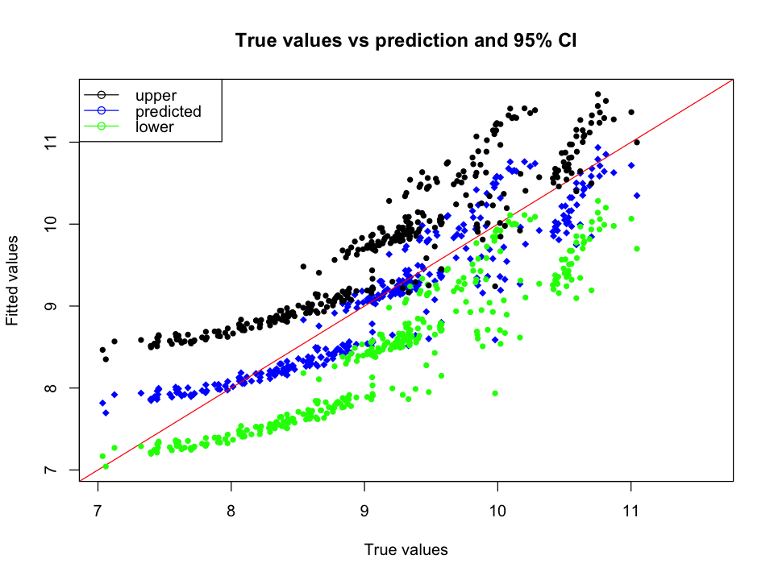

```r
predict_interval = predict_output$fit
plot(test_response, predict_interval[,'fit'], xlim = range(predict_interval),
     ylim =  range(predict_interval), xlab = "True values", ylab = "Fitted values",
    type = "p", pch = 18, col = "blue", main = "True values vs prediction and 95% CI")
abline(0, 1, col = "red")

points(test_response,predict_interval[,'lwr'],type = "p", pch = 20, col = "green")
points(test_response,predict_interval[,'upr'],type = "p", pch = 20, col = "black")
legend("topleft", legend = c("upper", "predicted", "lower"), col = c("black", "blue", "green"), pch = 1, lwd = 1)
```